# Week 3 Assignment

Joshua Goldberg

November, 04 2018

**This project helps understanding beta prior distribution for binomial data**

# 1 Estimating the Risk of Tumor in a Group of Rats

## 1.1 Data

In example from Section 5.1 of [G] the goal was estimation of the probability $\theta$ of tumor in a population of female laboratory rats of type “F344” that receive a zero dose of the drug (control group). In the experiment 4 out of 14 rats developed a tumor.

```r
Data <- c(s = 14, k = 4)
```

## 1.2 Model

Select binomial model $yi∼Binom(\theta)$ with probability of tumor $\theta$ and beta prior distribution for the parameter $\theta∼Beta(\alpha,\beta)$.

Suppose we know from historical observation of population of “F344” the mean and the variance of beta distribution for $\theta$.

Using formulas in the interactive demonstration of beta distribution convert mean value $\mu=0.136$ and standard deviation $\sigma=0.1034$ of observed empirical probabilities into shapes of beta distribution $\alpha,\beta$.

```r
mu <- .136
sigma_squared <- .1034^2
a <- ((1 - mu) / sigma_squared - 1 / mu) * (mu^2)
b <- a * (1 / mu - 1)

cbind(a, b)
```

```
##             a        b
## [1,] 1.358688 8.631663
```

```r
x <- seq(from = 0, to = 1, by = .001)
priorBetaDens <- dbeta(x, shape1 = a, shape2 = b)
x[which.max(priorBetaDens)]
```

```
## [1] 0.045
```

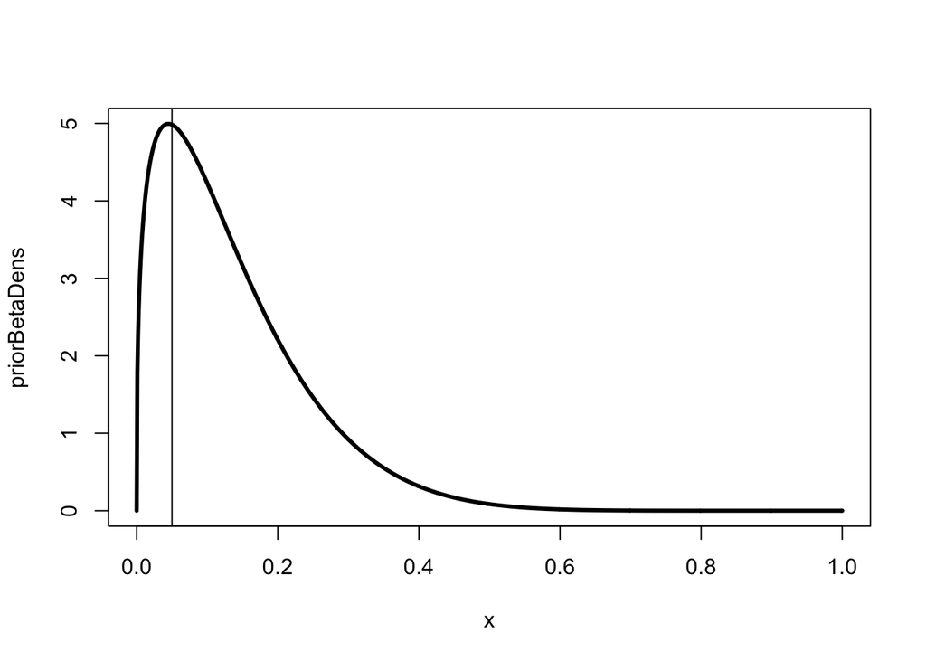

```r
plot(x, priorBetaDens, type = "l", lwd = 3)
abline(v = .05)
```

## 1.3 Posterior distribution by formulas

Calculate parameters of posterior distribution.

```r
postA <- Data["k"][[1]] + a
postB <- Data["s"][[1]] - Data["k"][[1]] + b
posteriorBetaDens <- dbeta(x, shape1 = postA, shape2 = postB)
c(postA = postA, postB = postB)
```

```
##     postA     postB
##  5.358688 18.631663
```

## 1.4 Comparison

Compare prior and posterior distributions and explain the difference.

```r
cbind(prior = x[which.max(priorBetaDens)], posterior = x[which.max(posteriorBetaDens)])
```

```
##      prior posterior
## [1,] 0.045     0.198
```

The posterior has shifted to the right, implying a somewhat weak prior. The mode has shifted meaningfully from the prior to the posterior. `b` was much larger relatively to `a` in the prior compared to the posterior.

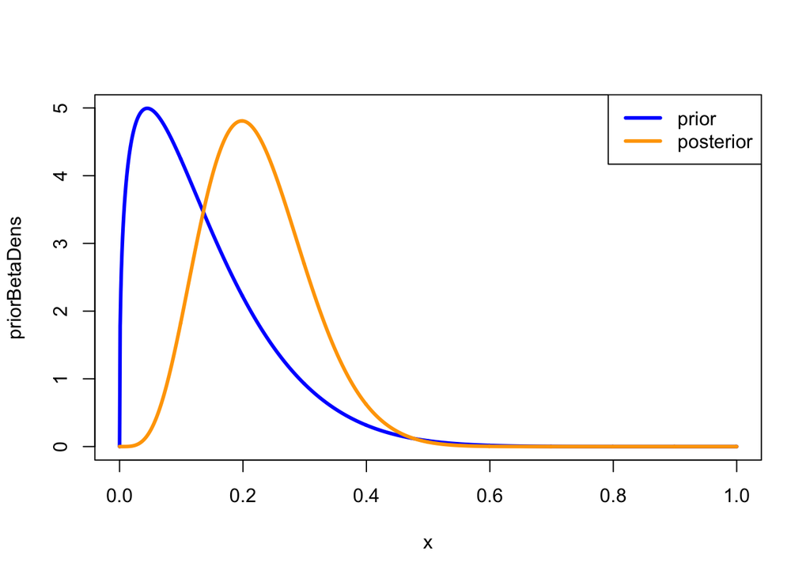

```r
plot(
  x,
  priorBetaDens,
  type = 'l',
  lwd = 3,
  col = 'blue',
)
lines(x, posteriorBetaDens, lwd = 3, col = 'orange')
legend(
  "topright",
  legend = c("prior", "posterior"),
  col = c("blue", "orange"),
  lwd = 3
)
```

Mean, variance, and concentration:

```r
muPosterior = postA / (postA + postB)
varPosterior <- postA * postB / (postA + postB) ^ 2 / (postA + postB + 1)
kappaPosterior <- postA + postB

prior_post <- rbind(cbind(mu, sigma_squared, kappa = a + b), cbind(muPosterior, varPosterior, kappaPosterior))
colnames(prior_post) <- c("mu", "var", "kappa")
rownames(prior_post) <- c("prior", "posterior")
prior_post
```

```
##                  mu         var     kappa
## prior     0.1360000 0.010691560  9.990351
## posterior 0.2233685 0.006941679 23.990351
```

The mean, variance, and concentration have all shifted dramatically from the prior.

## 1.5 Grid approximation

In addition
$$\omega∼Beta(A_\omega,B_\omega)$$

Belief based on historical observations is that parameter $\omega$ has a tendency to be around 0.4 with concentration 12.

```r
omega <- .4
K <- 12
(A_omega <- omega * (K - 2) + 1)
```

```
## [1] 5
```

```r
(B_omega <- (1 - omega) * (K - 2) + 1)
```

```
## [1] 7
```

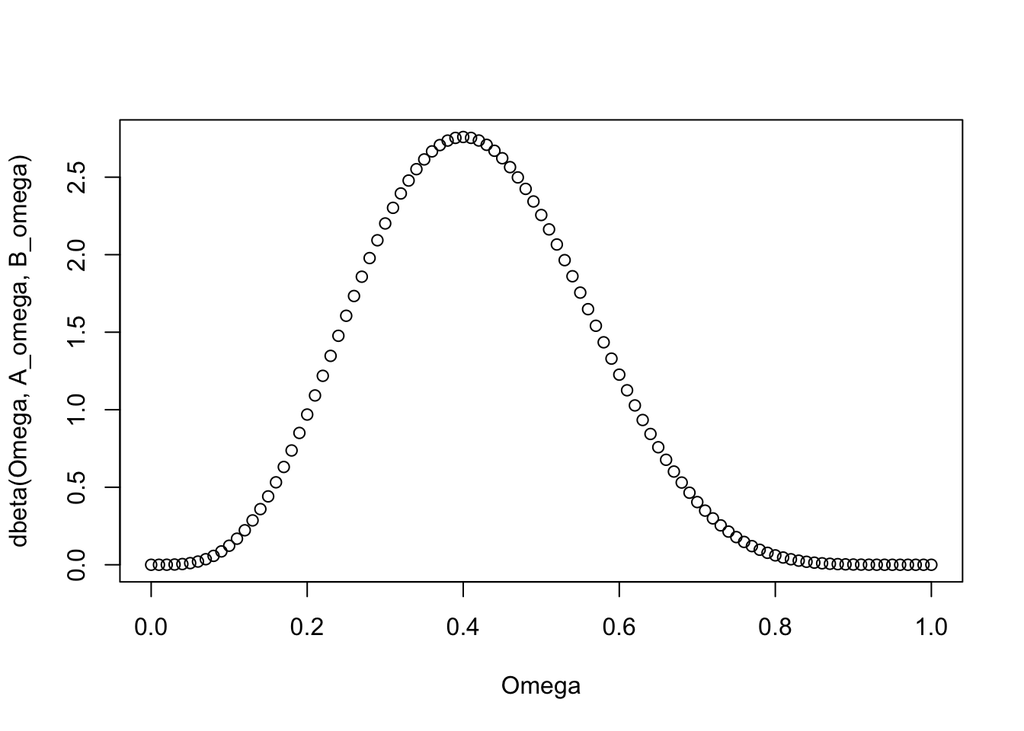

```r
K_theta <- 20

Omega <- Theta <- seq(0 , 1 , length = 101)
plot(Omega, dbeta(Omega, A_omega, B_omega))
```

### 1.5.1 Find joint prior distribution and marginals for $\theta$ and $\omega$

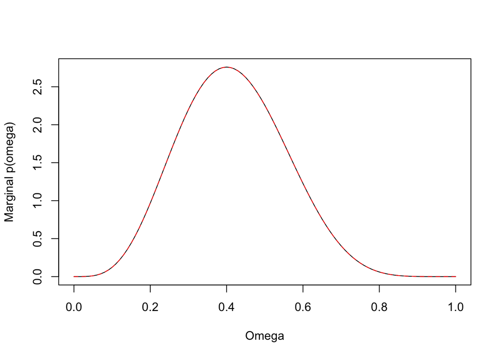

```r
jointPrior <- function(theta, omega, A_omega, B_omega, K) {
  dbeta(omega, A_omega, B_omega) * dbeta(theta, omega * (K - 2) + 1, (1 - omega) * (K - 2) + 1)
}

dens <- expand.grid(Omega, Theta)
colnames(dens) <- c("Omega", "Theta")
dens$Prior <- apply(dens, 1, function(z) jointPrior(z[1], z[2], A_omega, B_omega, K))
Prior.theta.omega <- matrix(dens$Prior, 101, 101)
Prior.theta.omega <- Prior.theta.omega / sum(Prior.theta.omega) #Joint prior
Prior.omega.marginal <- apply(Prior.theta.omega, 2, sum)
Prior.omega.marginal <- Prior.omega.marginal / sum(Prior.omega.marginal) * 100 #Omega marginal prior
matplot(Omega,
        cbind(Prior.omega.marginal, dbeta(Omega, A_omega, B_omega)),
        type = "l",
        ylab = "Marginal p(omega)")
```

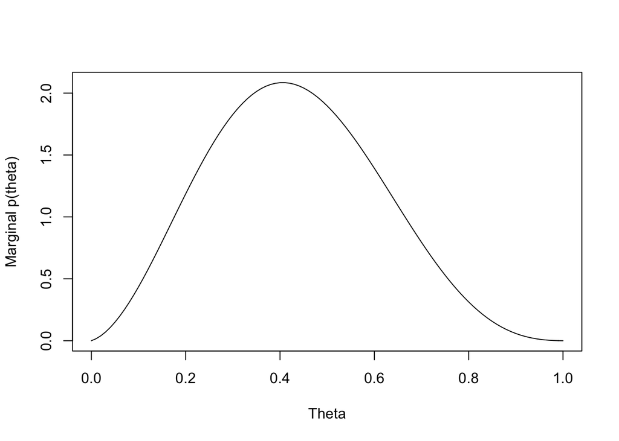

```r
Prior.theta.marginal <- apply(Prior.theta.omega, 1, sum)
Prior.theta.marginal <- Prior.theta.marginal / sum(Prior.theta.marginal) * 100 #Theta marginal prior
plot(Theta, Prior.theta.marginal, type = "l", ylab = "Marginal p(theta)")
```

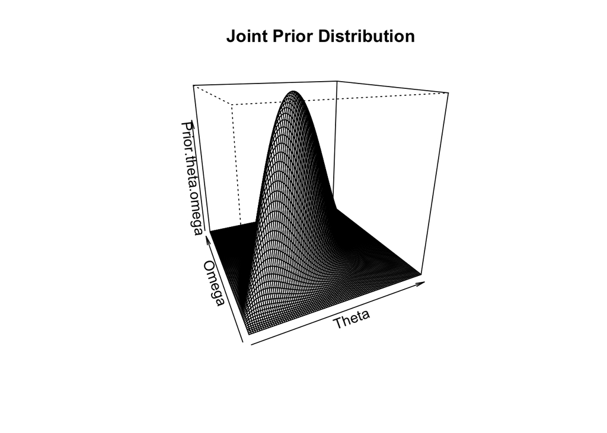

```r
persp(
  Theta,
  Omega,
  Prior.theta.omega,
  d = 1,
  theta = -25,
  phi = 20,
  main = "Joint Prior Distribution"
)
```

The contour plot shows as $\omega$ increases, $\theta$ follows:

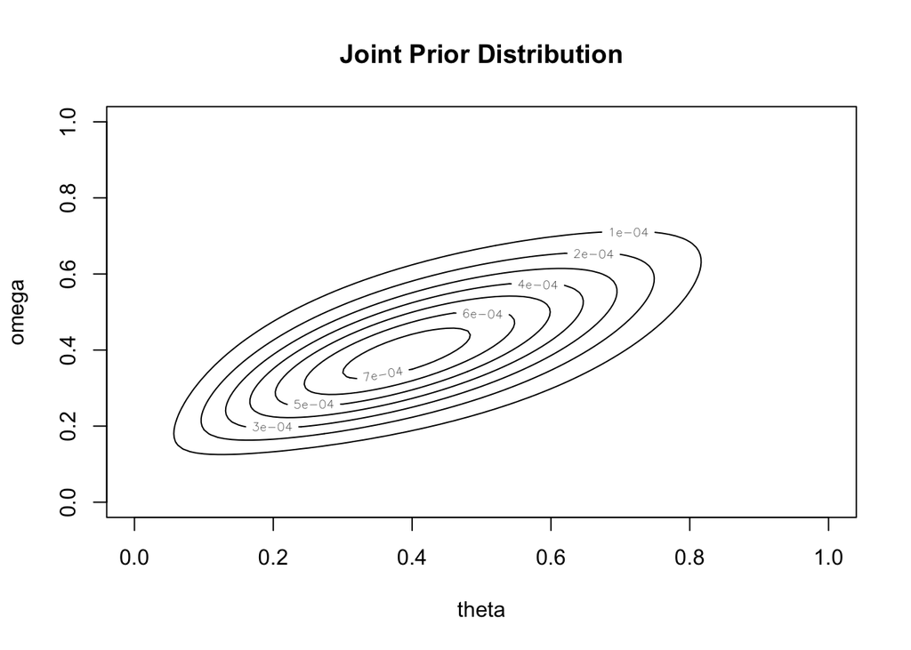

```r
contour(
  x = Omega,
  y = Theta,
  z = Prior.theta.omega,
  ylab = "omega",
  xlab = "theta",
  main = "Joint Prior Distribution"
)
```

Dependence is strong and positive between $\theta$ and prior. As $\omega$ increases, $\theta$ increases due to low $\kappa$.

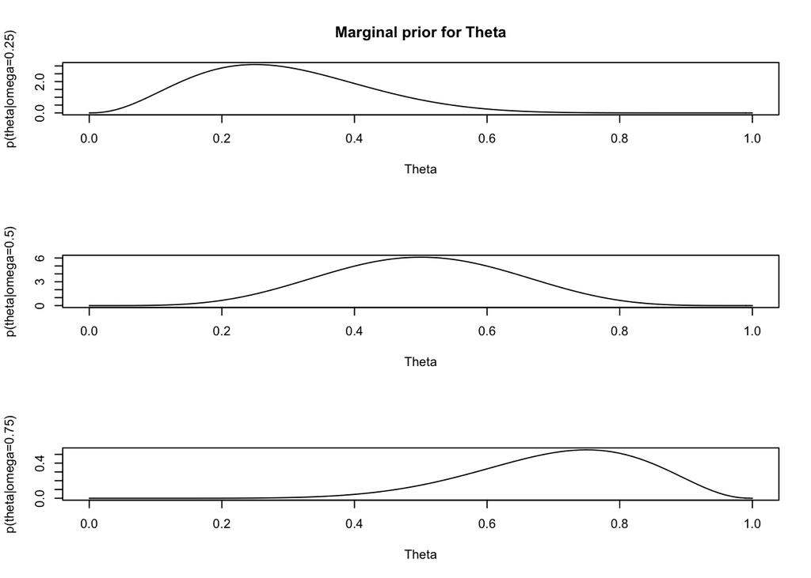

```r
par(mfrow = c(3, 1))
Prior.theta.omega.25 <- jointPrior(Theta, 0.25, A_omega, B_omega, K)
Prior.theta.omega.25 <- Prior.theta.omega.25 / sum(Prior.theta.omega.25) * 100
plot(
  Theta,
  Prior.theta.omega.25,
  type = "l",
  ylab = "p(theta|omega=0.25)",
  main = "Marginal prior for Theta"
)

Prior.theta.omega.5 <- jointPrior(Theta, 0.5, A_omega, B_omega, K)
Prior.theta.omega.5 <- Prior.theta.omega.5 / sum(Prior.theta.omega.5) * 100
plot(Theta,
     jointPrior(Theta, 0.5, A_omega, B_omega, K),
     type = "l",
     ylab = "p(theta|omega=0.5)")

Prior.theta.omega.75 <- jointPrior(Theta, 0.75, A_omega, B_omega, K)
Prior.theta.omega.75 <- Prior.theta.omega.75 / sum(Prior.theta.omega.75) * 100
plot(Theta,
     jointPrior(Theta, 0.75, A_omega, B_omega, K),
     type = "l",
     ylab = "p(theta|omega=0.75)")
```

### 1.5.3 Find likelihood function for the observed data

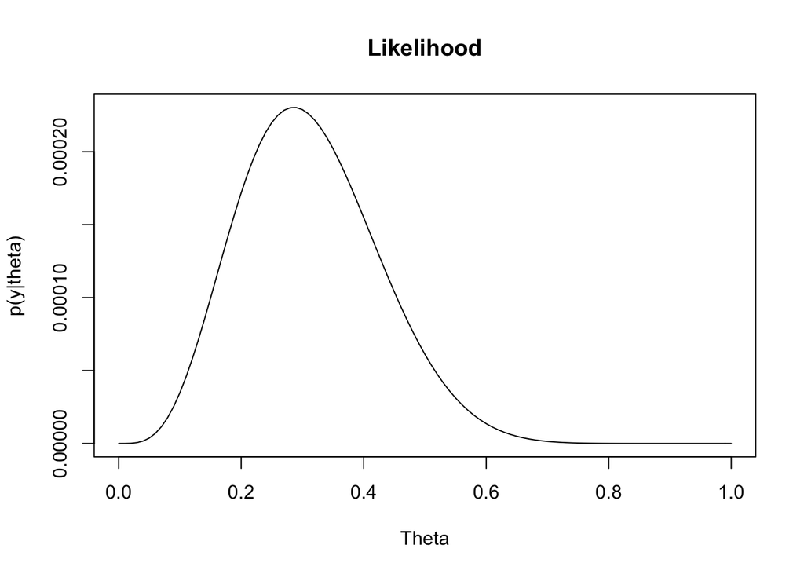

```r
likeli <- function(theta, s, k) {
  theta ^ k * (1 - theta) ^ (s - k)
}

likelihood <- likeli(Theta, Data[[1]], Data[[2]])
plot(Theta,
     likelihood,
     type = "l",
     ylab = "p(y|theta)",
     main = "Likelihood")
```

### 1.5.4 Find and plot joint posterior distribution for $\theta,\omega$ and the marginals

```r
Posterior <- apply(Prior.theta.omega, 2, function(z) z * likelihood)
Posterior <- Posterior / sum(Posterior)
Posterior[1:5, 1:5]
```

```
##      [,1]         [,2]         [,3]         [,4]         [,5]
## [1,]    0 0.000000e+00 0.000000e+00 0.000000e+00 0.000000e+00
## [2,]    0 1.499035e-12 1.865702e-11 7.242850e-11 1.732724e-10
## [3,]    0 2.100358e-11 2.804580e-10 1.168097e-09 2.998076e-09
## [4,]    0 9.028717e-11 1.256768e-09 5.456582e-09 1.459954e-08
## [5,]    0 2.389543e-10 3.426793e-09 1.532842e-08 4.225321e-08
```

Plot the joint posterior distribution.

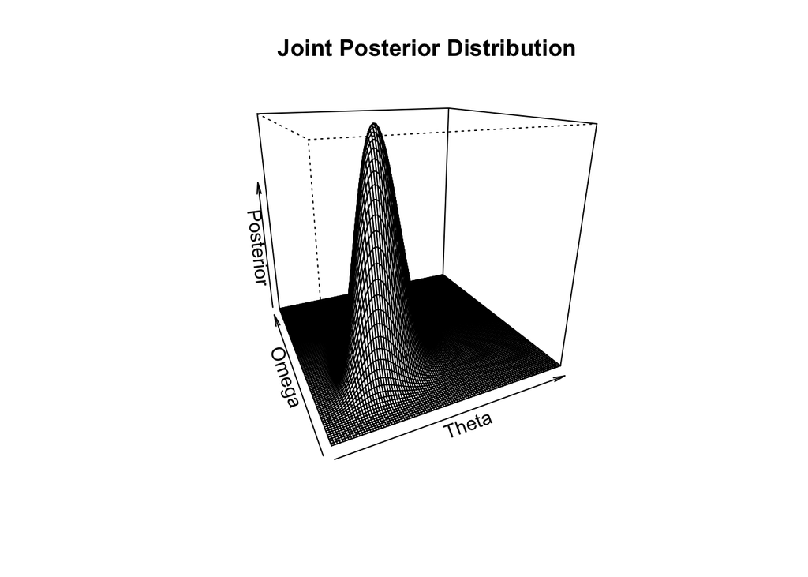

```r
persp(
  Theta,
  Omega,
  Posterior,
  d = 1,
  theta = -25,
  phi = 20,
  main = "Joint Posterior Distribution"
)
```

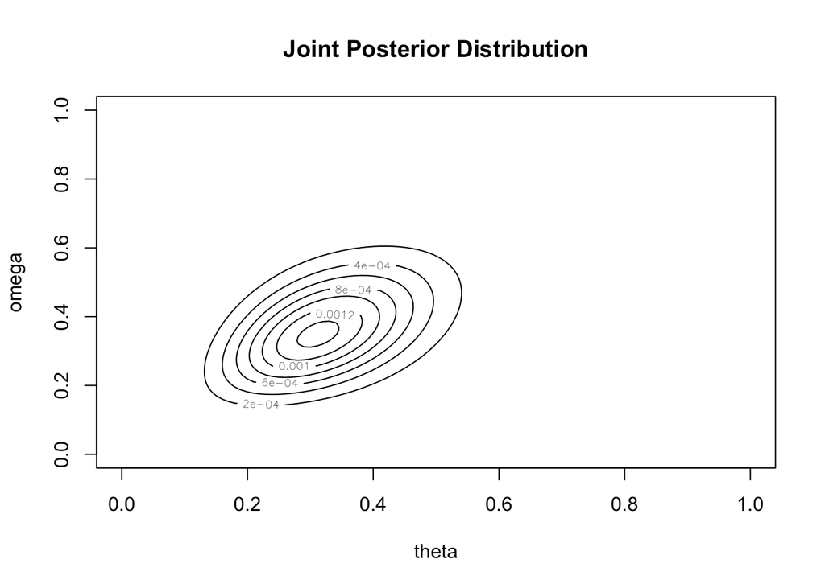

```r
contour(
  x = Theta,
  y = Omega,
  z = Posterior,
  ylab = "omega",
  xlab = "theta",
  main = "Joint Posterior Distribution"
)
```

Calculate and plot posterior marginal distributions $p(\theta|y)$, $p(\omega|y)$ by adding the joint posterior matrix by row or by column.

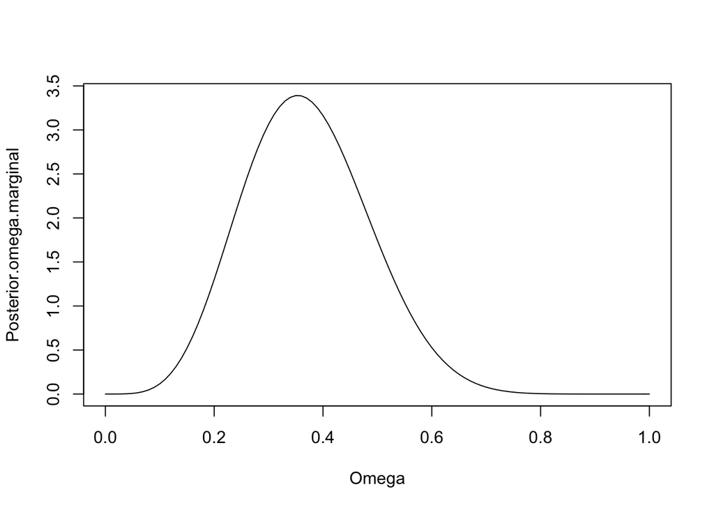

```r
Posterior.omega.marginal <- apply(Posterior, 2, sum)
Posterior.omega.marginal <- Posterior.omega.marginal / sum(Posterior.omega.marginal) * 100
plot(Omega, Posterior.omega.marginal, type = "l")
```

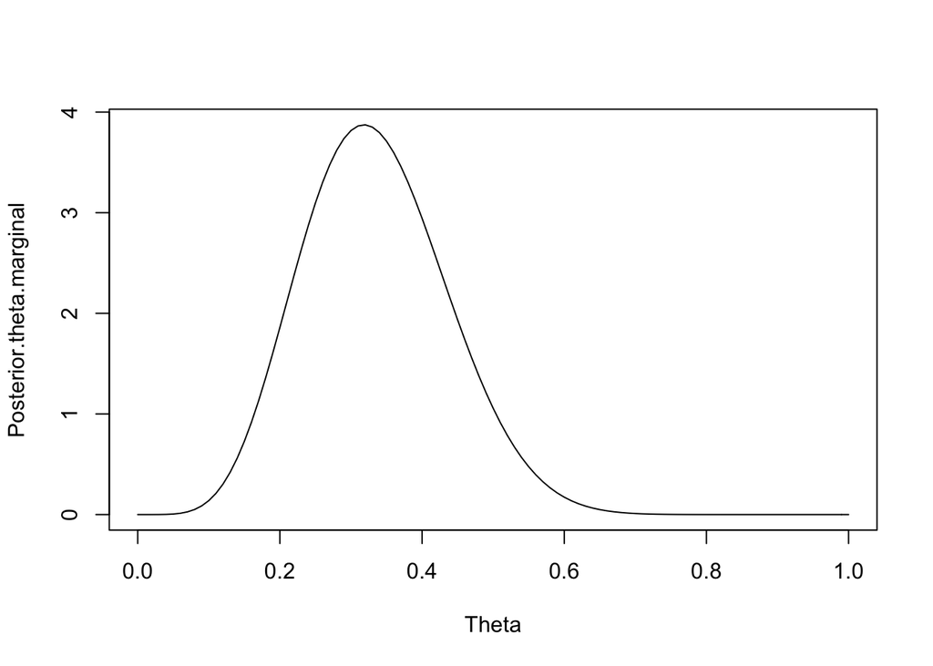

```r
Posterior.theta.marginal <- apply(Posterior, 1, sum)
Posterior.theta.marginal <- Posterior.theta.marginal / sum(Posterior.theta.marginal) * 100
plot(Theta, Posterior.theta.marginal, type = "l")
```

### 1.5.5 Observe and interpret dependence of $\theta$ on $\omega$ based on posterior distributions

As $\omega$ increases, $\theta$ follows similar to the prior. However, the relationship is not as pronounced. This is because $\kappa$ increased for the posterior.

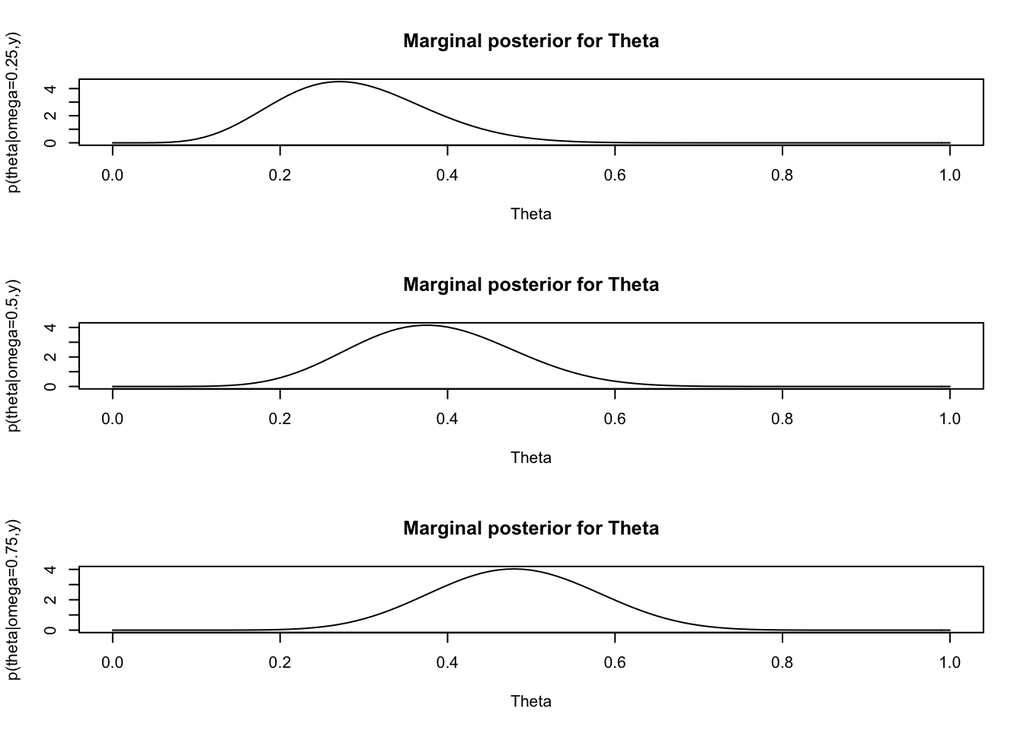

```r
par(mfrow = c(3, 1))

# Omega = 0.25
Post.theta.omega.25 <- Posterior[, match(0.25, Omega)]
Post.theta.omega.25 <-
  Post.theta.omega.25 / sum(Post.theta.omega.25) * 100
plot(
  Theta,
  Post.theta.omega.25,
  type = "l",
  ylab = "p(theta|omega=0.25,y)",
  main = "Marginal posterior for Theta"
)

# Omega = 0.5
Post.theta.omega.5 <- Posterior[, match(0.5, Omega)]
Post.theta.omega.5 <- Post.theta.omega.5 / sum(Post.theta.omega.5) * 100
plot(
  Theta,
  Post.theta.omega.5,
  type = "l",
  ylab = "p(theta|omega=0.5,y)",
  main = "Marginal posterior for Theta"
)

# Omega = 0.75
Post.theta.omega.75 <- Posterior[, match(0.75, Omega)]
Post.theta.omega.75 <-
  Post.theta.omega.75 / sum(Post.theta.omega.75) * 100
plot(
  Theta,
  Post.theta.omega.75,
  type = "l",
  ylab = "p(theta|omega=0.75,y)",
  main = "Marginal posterior for Theta"
)
```

### 1.5.6 Compare marginal priors and posteriors for both parameters

The marginal posterior for $\omega$ does not shift much relative to the change in marginal $\theta$

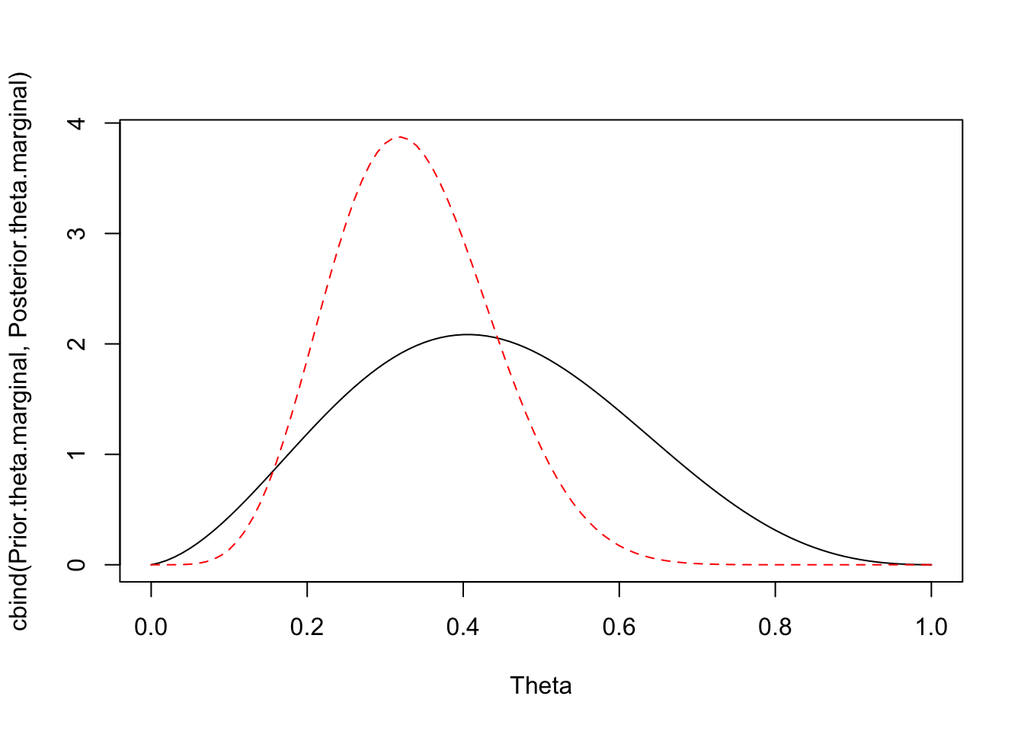

```r
matplot(Theta,
        cbind(Prior.theta.marginal, Posterior.theta.marginal),
        type = "l")
```

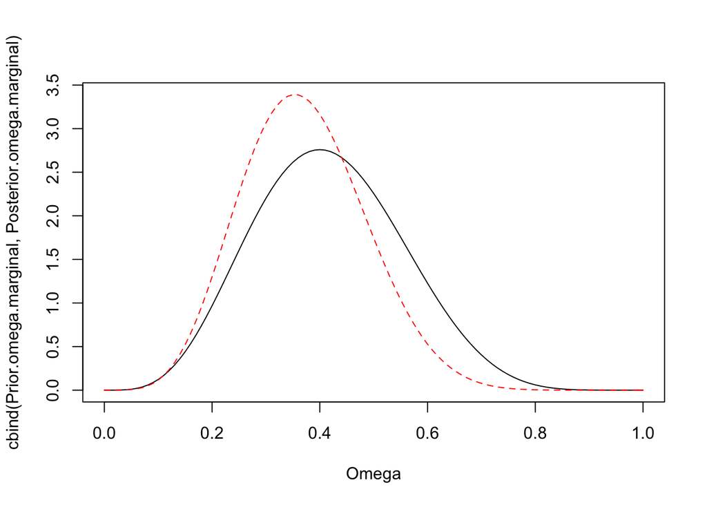

```r
matplot(Omega,
        cbind(Prior.omega.marginal, Posterior.omega.marginal),
        type = "l")
```

### 1.5.7 Compare conditional priors and posteriors for $\theta$

The conditional posterior for $\theta$ changes meaningfully from the prior. We see the same positive dependence between $\omega$ and $\theta$ that we saw in the contour and multiple plots above.

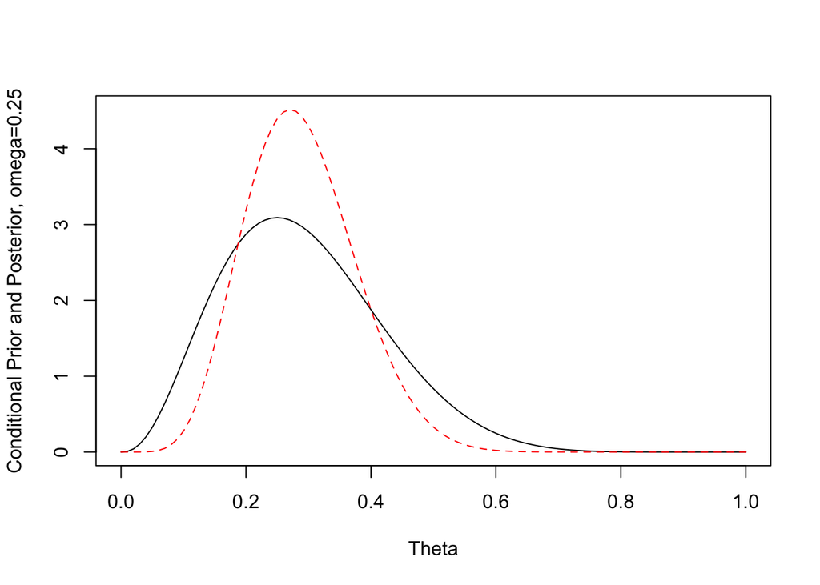

```r
matplot(
  Theta,
  cbind(Prior.theta.omega.25, Post.theta.omega.25),
  type = "l",
  ylab = "Conditional Prior and Posterior, omega=0.25"
)
```

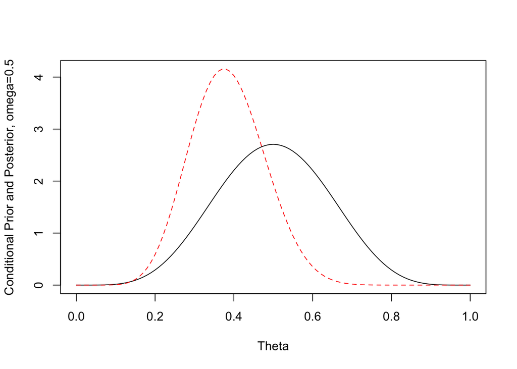

```r
matplot(
  Theta,
  cbind(Prior.theta.omega.5, Post.theta.omega.5),
  type = "l",
  ylab = "Conditional Prior and Posterior, omega=0.5"
)
```

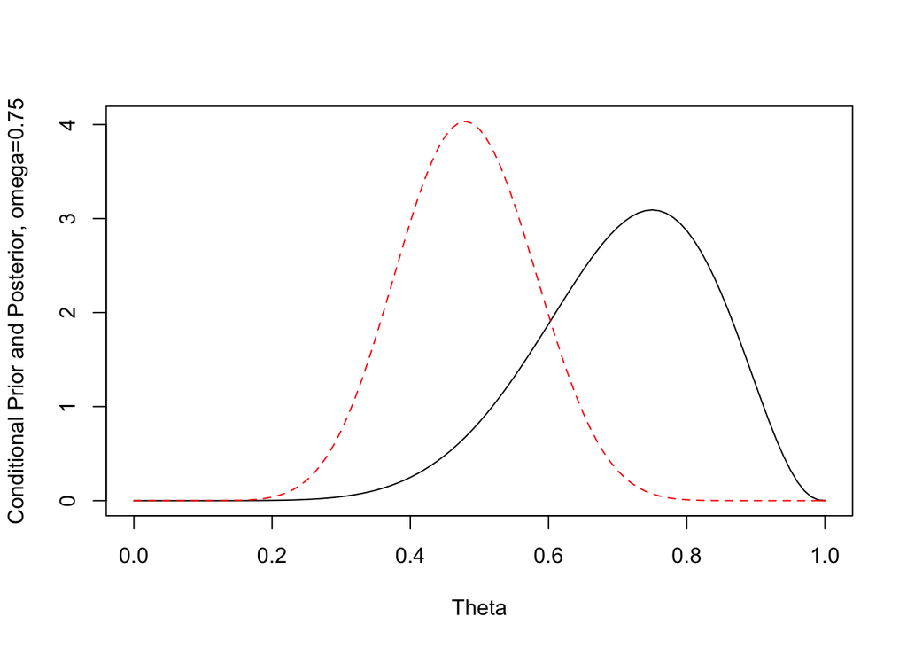

```r
matplot(
  Theta,
  cbind(Prior.theta.omega.75, Post.theta.omega.75),
  type = "l",
  ylab = "Conditional Prior and Posterior, omega=0.75"
)
```